# R Notebook

```r
data(tips, package="reshape2")
library(dplyr)
```

```r
library(ggplot2)
```

```r
numParty <- nrow(tips)
print(numParty)
```

```
## [1] 244
```

```r
print(tips)
```

```
##     total_bill   tip    sex smoker  day   time size
## 1        16.99  1.01 Female     No  Sun Dinner    2
## 2        10.34  1.66   Male     No  Sun Dinner    3
## 3        21.01  3.50   Male     No  Sun Dinner    3
## 4        23.68  3.31   Male     No  Sun Dinner    2
## 5        24.59  3.61 Female     No  Sun Dinner    4
## 6        25.29  4.71   Male     No  Sun Dinner    4
## 7         8.77  2.00   Male     No  Sun Dinner    2
## 8        26.88  3.12   Male     No  Sun Dinner    4
## 9        15.04  1.96   Male     No  Sun Dinner    2
## 10       14.78  3.23   Male     No  Sun Dinner    2
## 11       10.27  1.71   Male     No  Sun Dinner    2
## 12       35.26  5.00 Female     No  Sun Dinner    4
## 13       15.42  1.57   Male     No  Sun Dinner    2
## 14       18.43  3.00   Male     No  Sun Dinner    4
```

[output cut: 230 more lines]

```r
print(names(tips))
```

```
## [1] "total_bill" "tip"        "sex"        "smoker"     "day"
## [6] "time"       "size"
```

total_bill: total sum of bill: double tip: tip included: double size: # of people in party: int sex: gender of person paying bill: category smoker: if the person paying bill: category day: day of the week going out: category time: specific meal: category

```r
newdata <- tips[order(tips$day, decreasing = TRUE),]
print(newdata)
```

```
##     total_bill   tip    sex smoker  day   time size
## 78       27.20  4.00   Male     No Thur  Lunch    4
## 79       22.76  3.00   Male     No Thur  Lunch    2
## 80       17.29  2.71   Male     No Thur  Lunch    2
## 81       19.44  3.00   Male    Yes Thur  Lunch    2
## 82       16.66  3.40   Male     No Thur  Lunch    2
## 83       10.07  1.83 Female     No Thur  Lunch    1
## 84       32.68  5.00   Male    Yes Thur  Lunch    2
## 85       15.98  2.03   Male     No Thur  Lunch    2
## 86       34.83  5.17 Female     No Thur  Lunch    4
## 87       13.03  2.00   Male     No Thur  Lunch    2
## 88       18.28  4.00   Male     No Thur  Lunch    2
## 89       24.71  5.85   Male     No Thur  Lunch    2
## 90       21.16  3.00   Male     No Thur  Lunch    2
## 118      10.65  1.50 Female     No Thur  Lunch    2
```

[output cut: 230 more lines]

```r
female5 <- tips[tips$size >= 5 & tips$sex == "Female",  ]
print(female5)
```

```
##     total_bill  tip    sex smoker  day   time size
## 126      29.80 4.20 Female     No Thur  Lunch    6
## 144      27.05 5.00 Female     No Thur  Lunch    6
## 156      29.85 5.14 Female     No  Sun Dinner    5
```

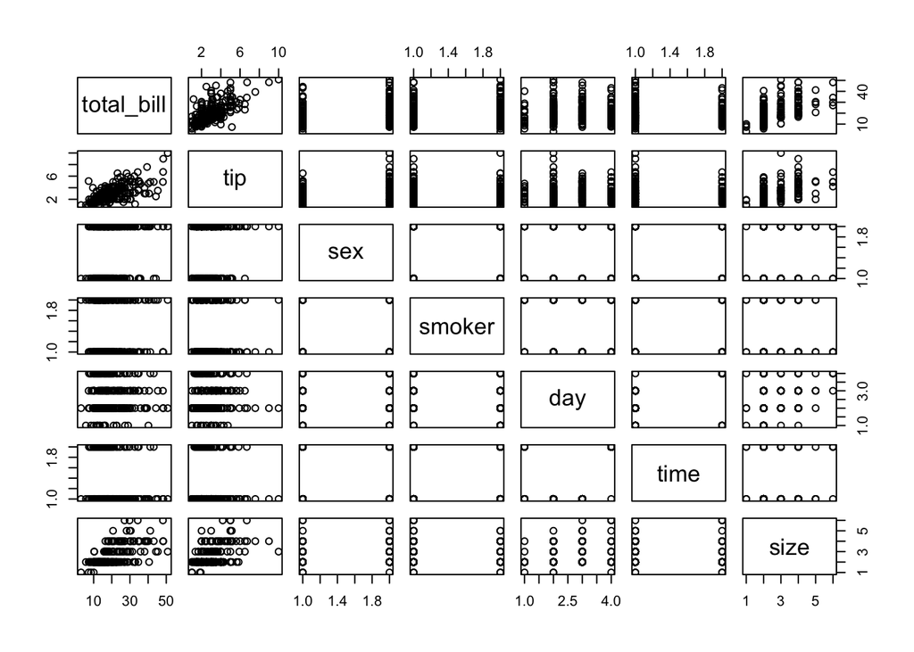

```r
plot(tips)
```

The lower the bill, the lower the tip typically and vice versa. Linear regression-like line.

6. There is a lot of data in the lower aspect of the graph, which makes it more difficult to predict later data. There also exists some outliers of people who tip really well/very poorly.

```r
tip_rate <- tips$tip / tips$total_bill
data <- tips %>%
  summarise(tiprate = mean(tip))

data2 <- tips %>%
  summarise(billrate = mean(total_bill))

avg_tip_rate <- data$tiprate/data2$billrate
print(avg_tip_rate)
```

```
## [1] 0.1515358
```

The rate is: about 15%

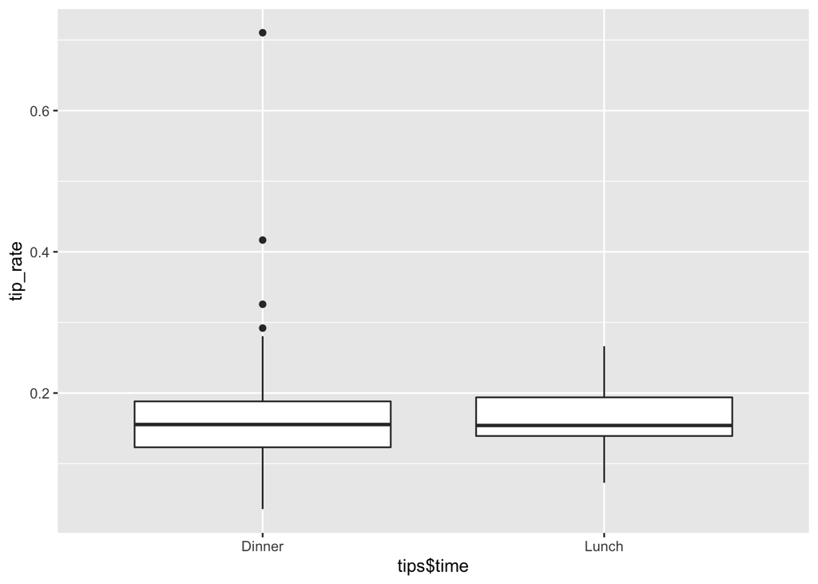

```r
my_plot <- ggplot(data = tips, aes(x = tips$time, y=tip_rate))
my_plot + geom_boxplot()
```

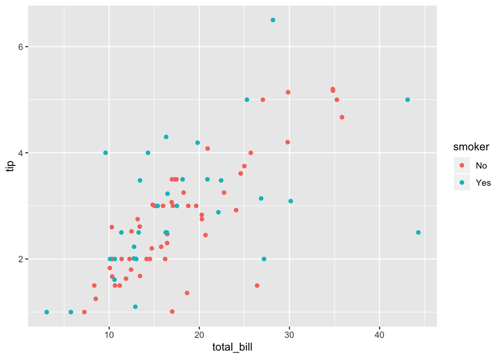

```r
female <- tips[tips$sex == "Female",  ]
male <- tips[tips$sex == "Male",  ]

my_plot <- ggplot(data=female, aes(x=total_bill, y=tip, color=smoker))
my_plot + geom_point()
```

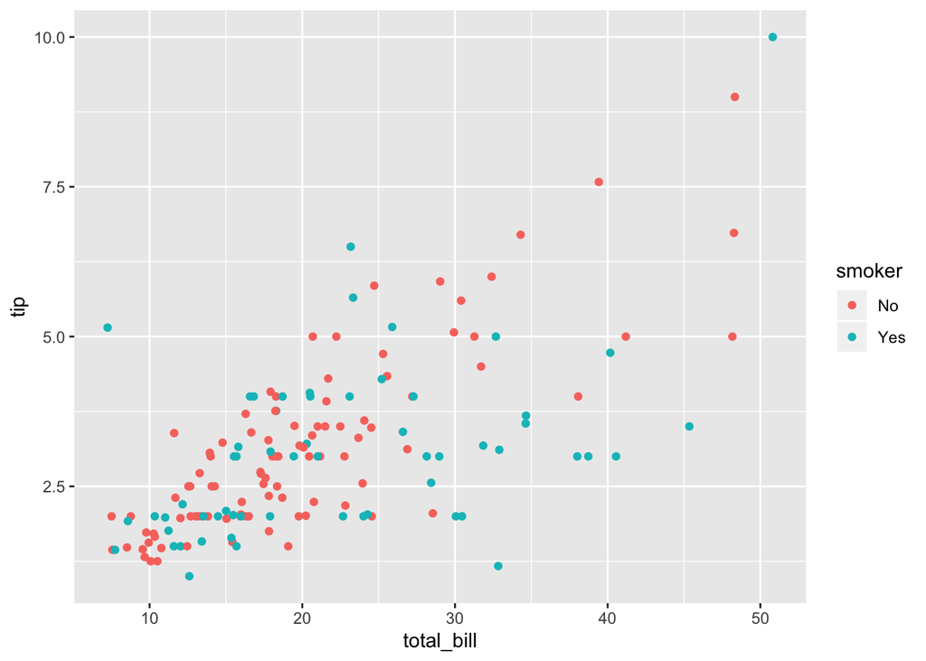

```r
my_plot <- ggplot(data=male, aes(x=total_bill, y=tip, color=smoker))
my_plot + geom_point()
```

A lot of the females had lower bills, which meant less tips.

Women who are smokers appear to tip less than women who are not smokers. There does not appear to be much of a correlation for men in regards to if they smoke or not when paying

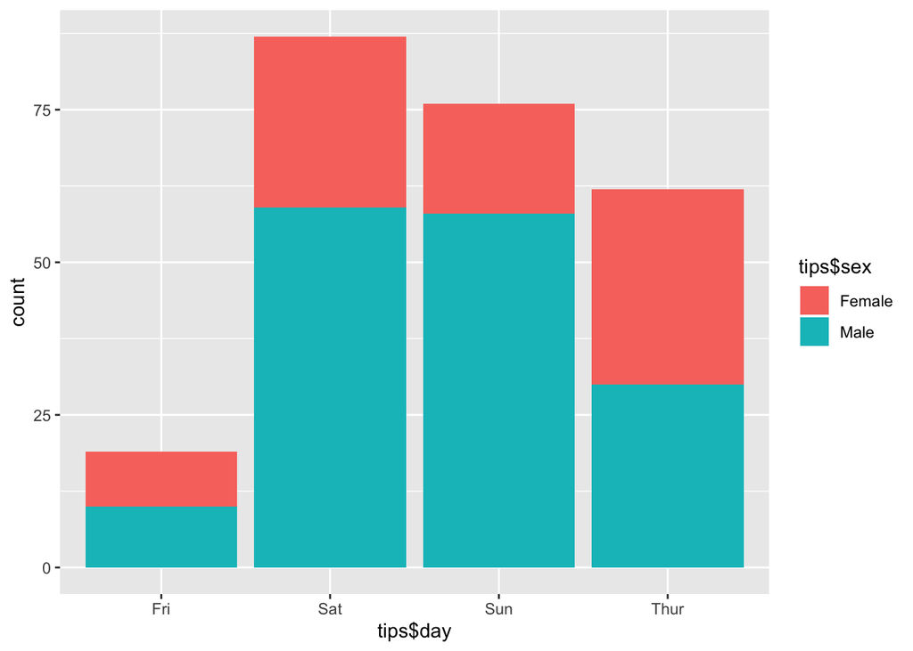

```r
my_plot <- ggplot(data=tips, aes(x=tips$day, fill=tips$sex))

my_plot + geom_bar()
```

Men are more likely to pay the bill on Saturday and Sunday. Women are more likely to pay on Thursdays. On Fridays men and women both are as likely to pay the bill as the other person.